# **projeto final de econometria**

# Decompisção Temporal

Seja uma série temporal cuja o modelo aditivo se dá de forma :

$$Z_t= sazonalidade_t + tendencia_t + ciclo_t + ε_t$$

a decomposição temporal é dada pela separação dessas variáveis

```python
decomposicao=seasonal_decompose(train,model='additive',period=30,extrapolate_trend=30)
```

Vamos utilizar a função **seasonal_decompese()** para decompor a nossa série temporal,lembrando que estamos analisando apenas o fechamento da bolsa brasileira, além disso, como o nosso modelo escolhido foi o modelp aditivo,vamos usar o parâmetro **model= addtive** , temos o parâmetro **period=30** que irá calcular a tendência ,sazonalidade,média móvel com base nesses 30 dias, que é um mês comercial(mês comercial tem 30 dias), por último temos o parâmetro **extrapolate_trend=30** evita que durante o cálculo a coluna fique nula, caso isso aconteça, a coluna será preenchida com o próprio dado.

Analisando o fechamento da bolsa de valor

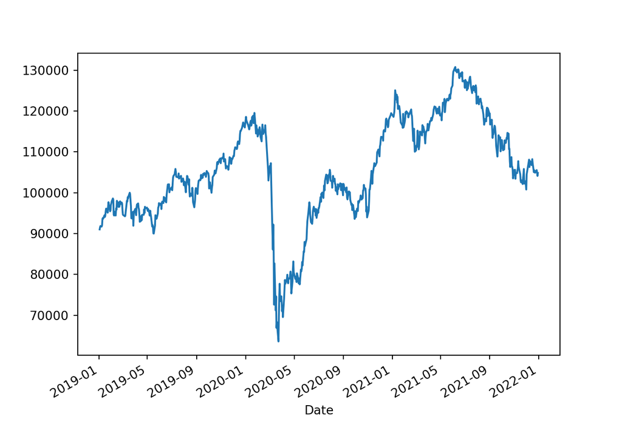

```python
train.plot()
```

A somas desses termos nos retorna a própria série temporal

```python
decomposicao.seasonal + decomposicao.resid+decomposicao.trend
```

```
## Date
## 2019-01-02     91012.0
## 2019-01-03     91564.0
## 2019-01-04     91841.0
## 2019-01-07     91699.0
## 2019-01-08     92032.0
##                 ...
## 2021-12-23    104891.0
## 2021-12-27    105531.0
## 2021-12-28    104864.0
## 2021-12-29    104107.0
## 2021-12-30    104822.0
## Length: 743, dtype: float64
```

## Plotle dos dados que série observada

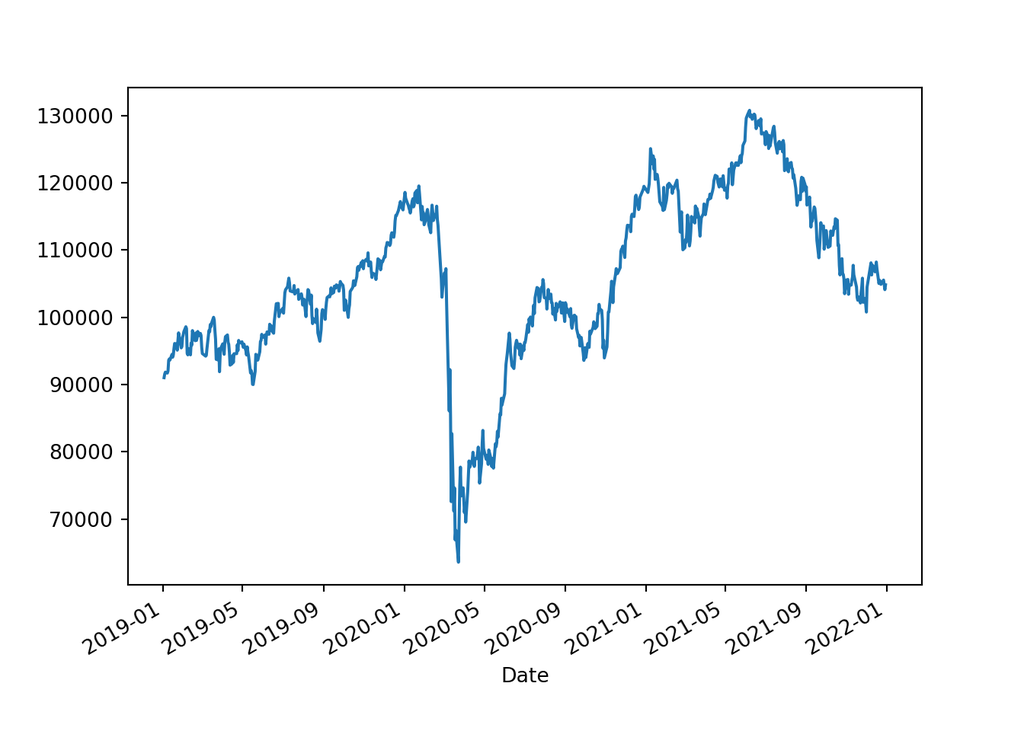

```python
train.plot()
```

## Plot da Decomposição da série

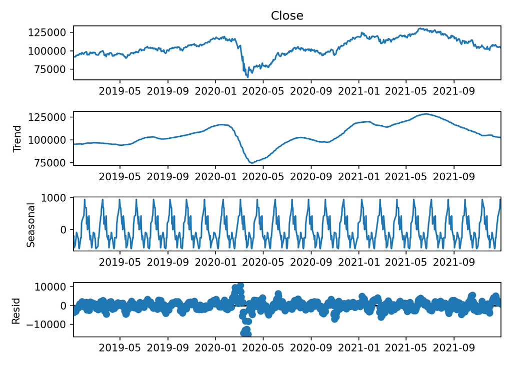

```python
decomposicao.plot()
```

Aqui podemos ver os gráficos decompostos , onde o primeiro gráfico é a série original , **trend** é a tendência , **Seasonal** é a sazonalidade e **resid** é o ruído .

# Teste Mann-Kendall

O teste Mann-Kendall verifica se realmente existe tendência na nossa série.

**Hipóteses:**

$H_0:$ Não há tendência presente nos dados. $P\ge0,05$

$H_1:$ Uma tendência está presente nos dados que pode ser de aumento ou de diminuição $P< 0,05$

```r
df<-train


dfi<-ts(df, start = c(2019, 1), end = c(2021, 12),
                           frequency = 12)
MannKendall(dfi)
```

```
## tau = -0.252, 2-sided pvalue =5.1163e-10
```

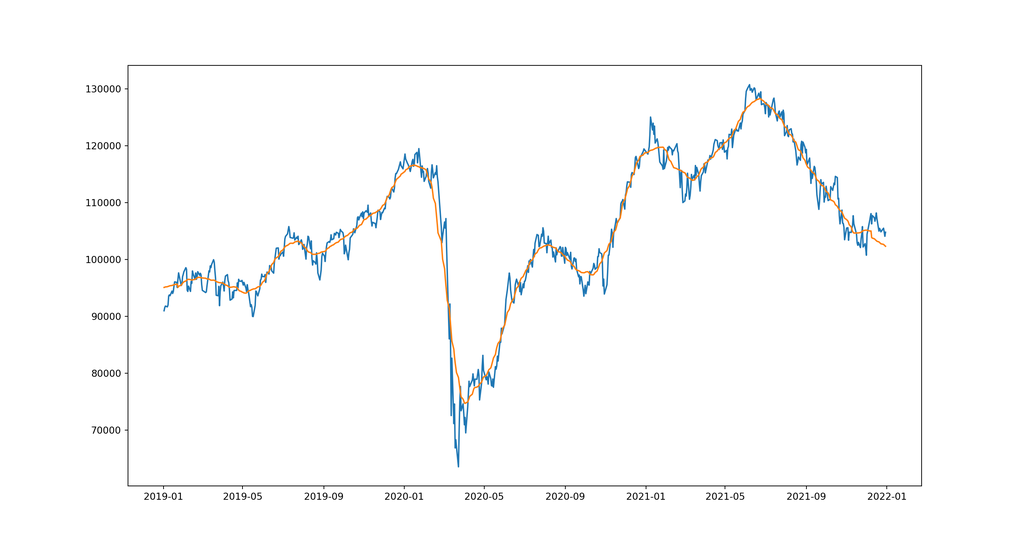

```python
fig,(ax1,ax2,ax3,ax4) =plt.subplots(4,1,figsize =(12,8))
decomposicao.observed.plot(ax=ax1)
decomposicao.trend.plot(ax=ax2)
decomposicao.seasonal.plot(ax=ax3)
decomposicao.resid.plot(ax=ax4)
plt.tight_layout()
ax,fig = plt.subplots(figsize=(15,8))
plt.plot(decomposicao.observed)
plt.plot(decomposicao.trend)
```

**decomposicao.observed**= nossa série

**linha laranja**= representa a tendência

pelo gráfico podemos observar que até o início de 2022 o Ibovespa estava com tendência de queda , mas existe outras possibilidades para que possamos identifica a tendência em nossa série ,podemos por exemplo realizar uma regressão , onde teremos

Assumindo agora que nós temos dados mensais podemos rodar a seguinte regressão:
$$FEC_t = α + βMes_t + ε_t$$

# Calculando a Tendência Linear dá Série

por que devemos calcular a tendência linear da nossa série? calculando a tendência linear

vamos conseguir explicar melhor o comportamento de tendência da nossa série , ou seja, caso tenhamos uma tendência linear positiva isto provavelmente indicará que estamos em um momento de valorização da bolsa, já se encontrarmos uma tendência negativo isto indicará que estamos em um momento de desvalorização da bolsa

```r
df<-py$df


dfi<-ts(df, start = c(2019, 1), end = c(2022, 3),
                           frequency = 12)

fec.ts<-df[4]

rownames(fec.ts)<-as.Date(rownames(fec.ts))

dfi<-ts(fec.ts, start = c(2019, 1), end = c(2022, 3),
                           frequency = 12)


fec.ts$mes<-months(as.Date(rownames(fec.ts)))

fec.ts$data<-as.Date(rownames(fec.ts))

fec<-lm(formula = fec.ts$Close ~ fec.ts$data)

summary(fec)
```

```
##
## Call:
## lm(formula = fec.ts$Close ~ fec.ts$data)
##
## Residuals:
##    Min     1Q Median     3Q    Max
## -39585  -5502    829   7389  19245
##
## Coefficients:
##               Estimate Std. Error t value Pr(>|t|)
## (Intercept) -2.452e+05  2.096e+04  -11.70   <2e-16 ***
## fec.ts$data  1.899e+01  1.134e+00   16.74   <2e-16 ***
## ---
## Signif. codes:  0 '***' 0.001 '**' 0.01 '*' 0.05 '.' 0.1 ' ' 1
##
## Residual standard error: 10590 on 781 degrees of freedom
## Multiple R-squared:  0.2641, Adjusted R-squared:  0.2631
## F-statistic: 280.3 on 1 and 781 DF,  p-value: < 2.2e-16
```

logo,$FEC_t$ será a nossa tendência linear. Em seguida temos as três séries no mesmo gráfico.

```r
df<-train[4]
dfi <- ts(df, start = c(2019,1),end = c(2021,12), freq=12)


#definindo os anos
anos <- seq(as.Date("2019/01/02"),as.Date("2021/12/30"),"months")



n<-1:36

pred<-lm(dfi~n)

dfide<-decompose(dfi)
```

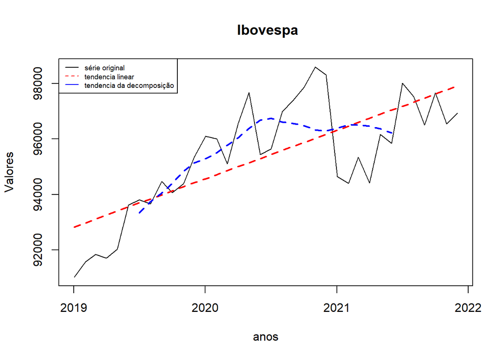

```r
plot(anos,dfi, type="l",main = " Ibovespa",ylab="Valores")
#plot(anos,pred$fitted.values)
lines(anos, pred$fitted.values, col= "red", lwd=2,lty=2)
lines(anos, dfide$trend, col= "blue", lwd=2,lty=2)
lines(anos,pred$residuals, type="l")

legend("topleft", legend = c("série original", "tendencia linear","tendencia da decomposição"),
       col = c("black","red" ,"blue"), lty = 1:2, cex = 0.6)
```

como podemos ver temos um Tendência linear positiva , logo ,a bolsa de valores Ibovespa vem se valorizando,pode ser um bom momento para investir na bolsa ,vamos observar com mais detalhes a frente

# Suavização Exponencial Simples

Os métodos de suavização exponencial são uma extensão do método ingênuo, em que as previsões são produzidas usando médias ponderadas de observações passadas, com os pesos decaindo exponencialmente à medida que as observações envelhecem. Em palavras simples, pesos maiores são dados às observações mais recentes e vice-versa. O valor do parâmetro de suavização para o nível é decidido pelo parâmetro ‘alpha’

```r
library(readr)
library(ggplot2)
library(forecast)
library(fpp2)
library(TTR)
library(dplyr)


se_model <- ses(dfi, h = 12)
summary(se_model)
```

```
##
## Forecast method: Simple exponential smoothing
##
## Model Information:
## Simple exponential smoothing
##
## Call:
##  ses(y = dfi, h = 12)
##
##   Smoothing parameters:
##     alpha = 0.8065
##
##   Initial states:
##     l = 91129.1906
##
##   sigma:  1132.35
##
##      AIC     AICc      BIC
## 639.2566 640.0066 644.0072
##
## Error measures:
##                    ME     RMSE      MAE       MPE      MAPE      MASE
## Training set 198.4711 1100.447 816.5878 0.2033237 0.8532609 0.3324418
##                      ACF1
## Training set -0.005268645
##
## Forecasts:
##          Point Forecast    Lo 80     Hi 80    Lo 95     Hi 95
## Jan 2022       96891.95 95440.78  98343.11 94672.58  99111.31
## Feb 2022       96891.95 95027.60  98756.30 94040.67  99743.22
## Mar 2022       96891.95 94690.65  99093.25 93525.35 100258.54
## Apr 2022       96891.95 94398.83  99385.07 93079.05 100704.84
## May 2022       96891.95 94137.76  99646.14 92679.78 101104.12
## Jun 2022       96891.95 93899.38  99884.52 92315.21 101468.69
## Jul 2022       96891.95 93678.63 100105.26 91977.61 101806.29
## Aug 2022       96891.95 93472.11 100311.79 91661.75 102122.14
## Sep 2022       96891.95 93277.36 100506.53 91363.91 102419.98
## Oct 2022       96891.95 93092.59 100691.31 91081.32 102702.57
## Nov 2022       96891.95 92916.39 100867.51 90811.85 102972.04
## Dec 2022       96891.95 92747.68 101036.22 90553.83 103230.06
```

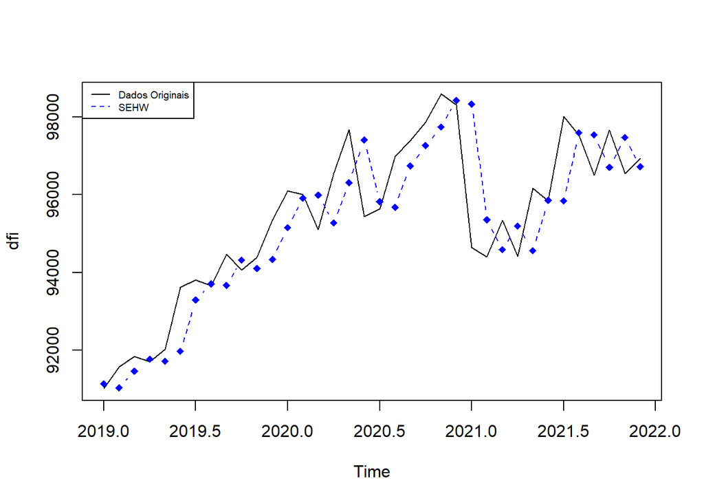

```r
plot(dfi)
lines(se_model$fitted,pch = 18, col = "blue", type = "b",
      lty = 2, lwd = 1,xlab="X-axis label", ylab="valores")
# 4. Add a legend to the plot and set legend lty
legend("topleft", legend = c("Dados Originais", "SEHW"),
       col = c("black", "blue"), lty = 1:2, cex = 0.6,)
```

aqui temos que o modelo de suavização simples não se ajustou adequadamente a série

```r
library(readr)
library(ggplot2)
library(forecast)
library(fpp2)
library(TTR)
library(dplyr)






se_model <- ses(dfi, h = 7)
summary(se_model)
```

```
##
## Forecast method: Simple exponential smoothing
##
## Model Information:
## Simple exponential smoothing
##
## Call:
##  ses(y = dfi, h = 7)
##
##   Smoothing parameters:
##     alpha = 0.8065
##
##   Initial states:
##     l = 91129.1906
##
##   sigma:  1132.35
##
##      AIC     AICc      BIC
## 639.2566 640.0066 644.0072
##
## Error measures:
##                    ME     RMSE      MAE       MPE      MAPE      MASE
## Training set 198.4711 1100.447 816.5878 0.2033237 0.8532609 0.3324418
##                      ACF1
## Training set -0.005268645
##
## Forecasts:
##          Point Forecast    Lo 80     Hi 80    Lo 95     Hi 95
## Jan 2022       96891.95 95440.78  98343.11 94672.58  99111.31
## Feb 2022       96891.95 95027.60  98756.30 94040.67  99743.22
## Mar 2022       96891.95 94690.65  99093.25 93525.35 100258.54
## Apr 2022       96891.95 94398.83  99385.07 93079.05 100704.84
## May 2022       96891.95 94137.76  99646.14 92679.78 101104.12
## Jun 2022       96891.95 93899.38  99884.52 92315.21 101468.69
## Jul 2022       96891.95 93678.63 100105.26 91977.61 101806.29
```

## plotagem do modelo

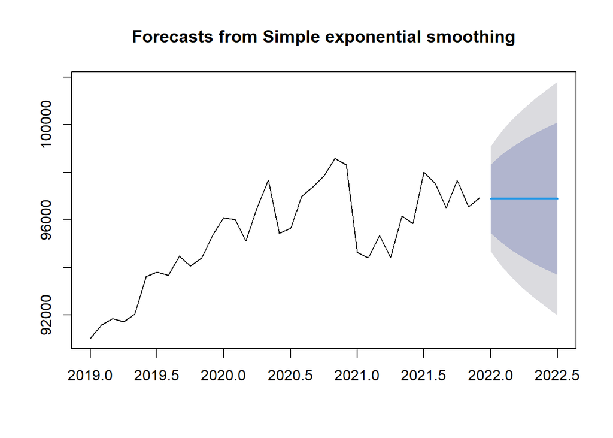

```r
library(readr)
library(ggplot2)
library(forecast)
library(fpp2)
library(TTR)
library(dplyr)








plot(se_model)
```

aqui temos a privisão feita com base a suavização exponecial

# Método de tendência de Holt

Esta é uma extensão do método de suavização exponencial simples que considera o componente de tendência ao gerar previsões. Este método envolve duas equações de suavização, uma para o nível e outra para o componente de tendência.

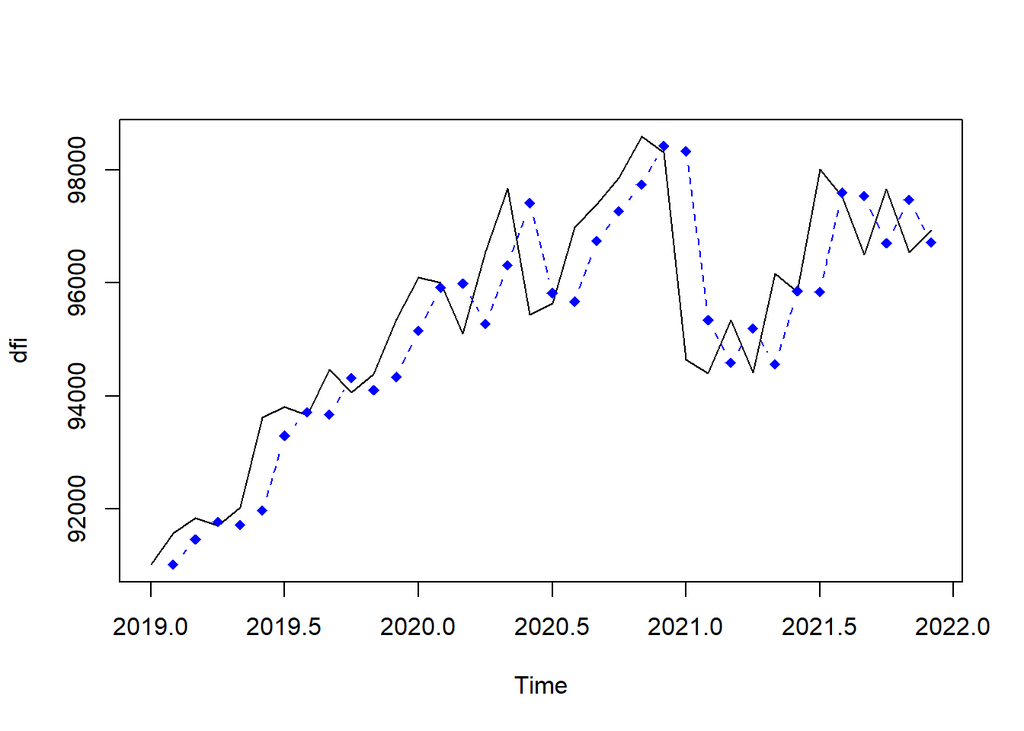

```r
holt_model <-HoltWinters(dfi,beta = F,gamma = F)


plot(dfi)
lines(holt_model$fitted[,1],pch = 18, col = "blue", type = "b",
      lty = 2, lwd = 1)
```

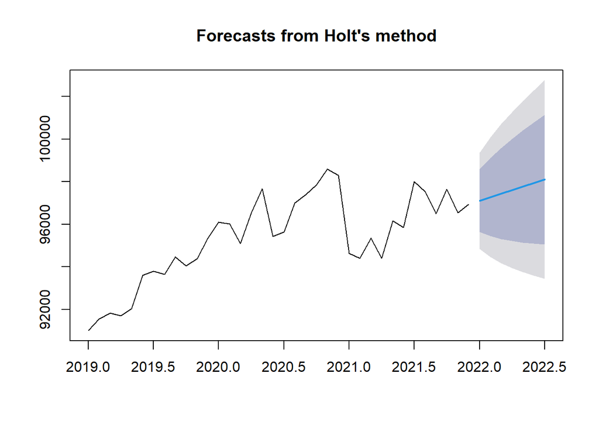

```r
holt_model <-holt(dfi, h = 7)


plot(holt_model)
```

podemos ver aqui qeu temos de fato uma tendencia de aumento ao logo do tempo , o seja , provavelmente seria interessante no atual momento adiquirir ações da Ibovepes para vender futuramente

# Cálculo da Média Movel

Realizando os principais calculos da média móvel

```python
media_movel5d=train.rolling(5).mean()
media_movel14d=train.rolling(14).mean()
media_movel21d=train.rolling(21).mean()

media_movel30d=train.rolling(30).mean()
```

### Plotagem da Média Móvel

O indicador médias móveis é um dos principais indicadores técnicos para tentar prever o início de uma tendência No preço de um ativo . As médias móveis se divide em médias curtas e médias longas, média curta tem 5 a 20 dias ela acompanha de forma mais próximo preço do ativo ,já a média loga tem de 20 a 60 dias

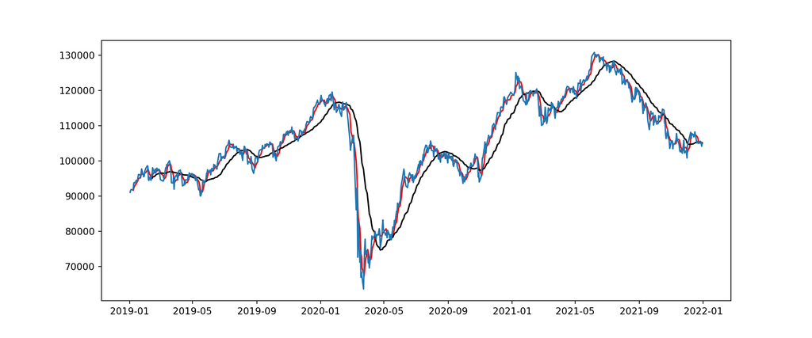

```python
fig,ax =plt.subplots(figsize=(12,5))
plt.plot(media_movel5d,'red')
plt.plot(media_movel30d,'black')
plt.plot(train)
```

A plotagem com ambas as médias de longa e curta distância são bastante utilizadas nas áreas de investimento ,Onde os pontos se cruzam será analisado se a tendência é positiva ou negativa para indicar o investimento ou venda de uma ação.

Exemplo : os pontos onde as médias móveis para 30 dias e para 5 dias se encontram é analisado a tendência , se essas médias se encontram em um ponto onde há tendência de crescimento devemos comprar ações , caso elas se cruzem em um determinado ponto e a tendência deterministica seja negativa ,ou seja, uma tendência de queda , devemos vender as ações.

# Para o modelo ARIMA

para que possamos utilizar o modelo Arima primeiro nossa série tem que atender o pressuposto de estacionaridade , então vamos verificar se nossa série é estacionária pelo teste **adf.test**(Augmented Dickey Fuller Test)

**hipotes:**

$H_0:$ a série é não estacionária. $P \ge 0,05$

$H_0:$ a série é estacionária. $P < 0,05$

```r
adf.test(dfi)
```

```
##
##  Augmented Dickey-Fuller Test
##
## data:  dfi
## Dickey-Fuller = -2.5054, Lag order = 3, p-value = 0.3765
## alternative hypothesis: stationary
```

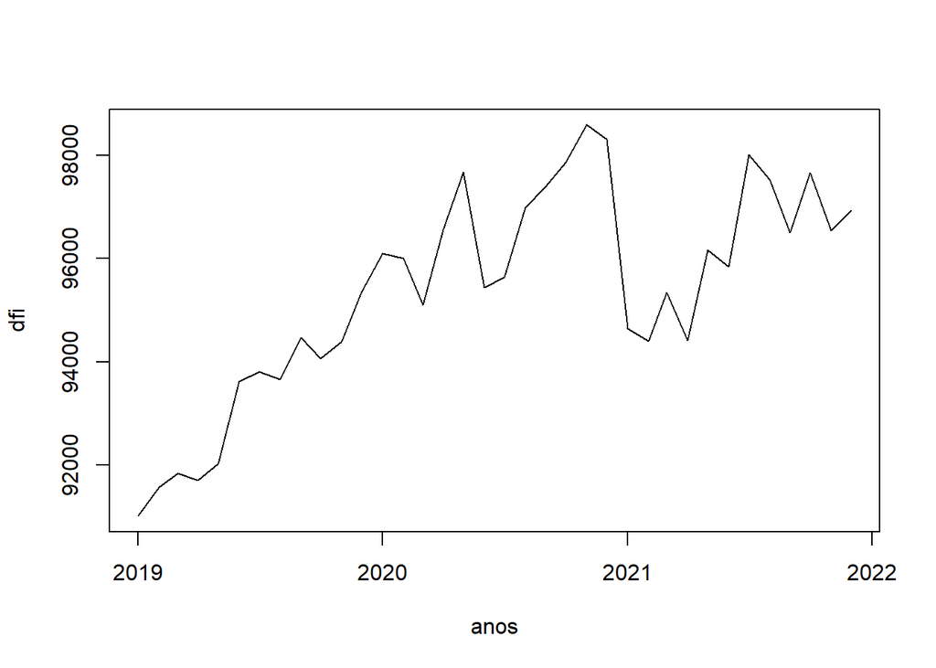

```r
anos <- seq(as.Date("2019/1/1"),as.Date("2021-12-31"),"months")

plot(anos,dfi,type="l")
```

como $p > 0,05$ temos que nossa série não é estacionária, então para usar o modelo Arima precisamos usar nosa série transformada , para isso vamos utilizar o comando **ndiffs()** para ver o numero de transfomações necessarias

```r
ndiffs(dfi)
```

```
## [1] 1
```

logo precisamos apenas de uma diferenciação para transformar nossa série em estacionária

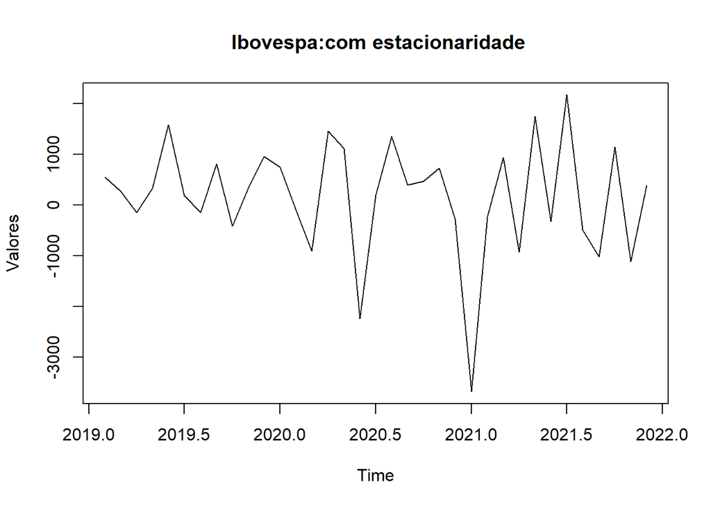

```r
fecdif = diff(dfi)

dfi1 <- ts(train, start = c(2019,2),end = c(2021,12), freq=12)


#definindo os anos
#anos <- seq(as.Date("2019/1/1"),as.Date("2022/03/1"),"months")

anos1<-seq(as.Date("2019/2/1"),as.Date("2021/12/31"),"months")



#pred1<-lm(dfi1~n)


anos1 <- seq(as.Date("2019/2/1"),as.Date("2022/03/1"),"months")
plot(fecdif, type="l",main = " Ibovespa:com estacionaridade",ylab="Valores")
```

Como podemos ver que nossa série é agora é estacionaria pois o seu valor médio oscila diante de uma raiz unitária(o zero )

## ajustando o modelo Arima

Para tentar minimizar a variação do ruído vamos utilizar a série em sua forma Logaritmica

```r
 #===============================================================================
#                         ajuste de modelo  ARima
#===============================================================================

library(dplyr)
library(fpp2)
require(forecast)
require(tseries)
require(Kendall)
library(lmtest)
library(readxl)
library(openxlsx)
library(timeSeries)
library(ggplot2)


df$date<-as.Date(rownames(df))


#dividindo em train e teste
#train<-df %>% dplyr::filter(df$date > "2018-12-31" & df$date < "2022-01-01" )


#teste<-df %>% dplyr::filter(df$date > "2021-12-31" & df$date < "2022-03-01" )




fect<-log(ts(train[1], start = c(2019,1),end = c(2021,12), freq=12))

modelo2<-Arima(fect,order = c(1,1,0),seasonal = c(1,1,0),lambda = T)
```

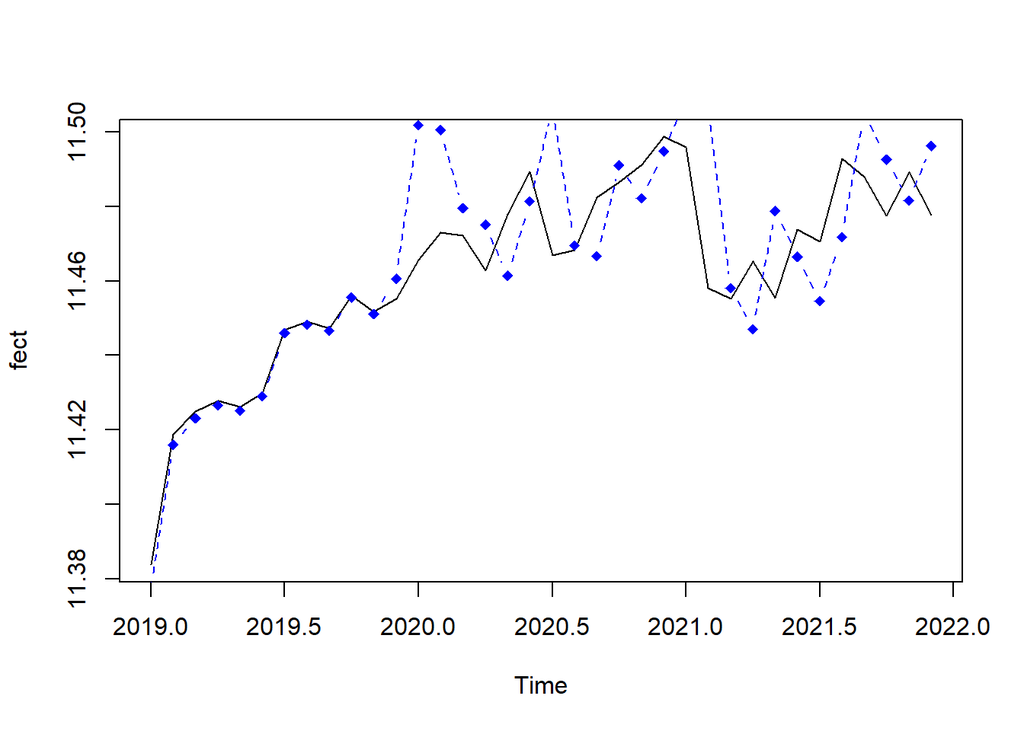

```r
plot(fect)
lines(modelo2$fitted,pch = 18, col = "blue", type = "b",
      lty = 2, lwd = 1)
```

Devido a baixa quantidade de dados o modelo se ajustou bem em alguns pontos , mas como tinhamos poucos dados , a maioria dos pontos não teve um excelente ajuste .

## Prevendo os valores pra Janeiro e Fevereiro

Para realizar as previsões para janeiro e fevereiro vamos utilizar a função **forecast** e o parâmetro **h =2**.

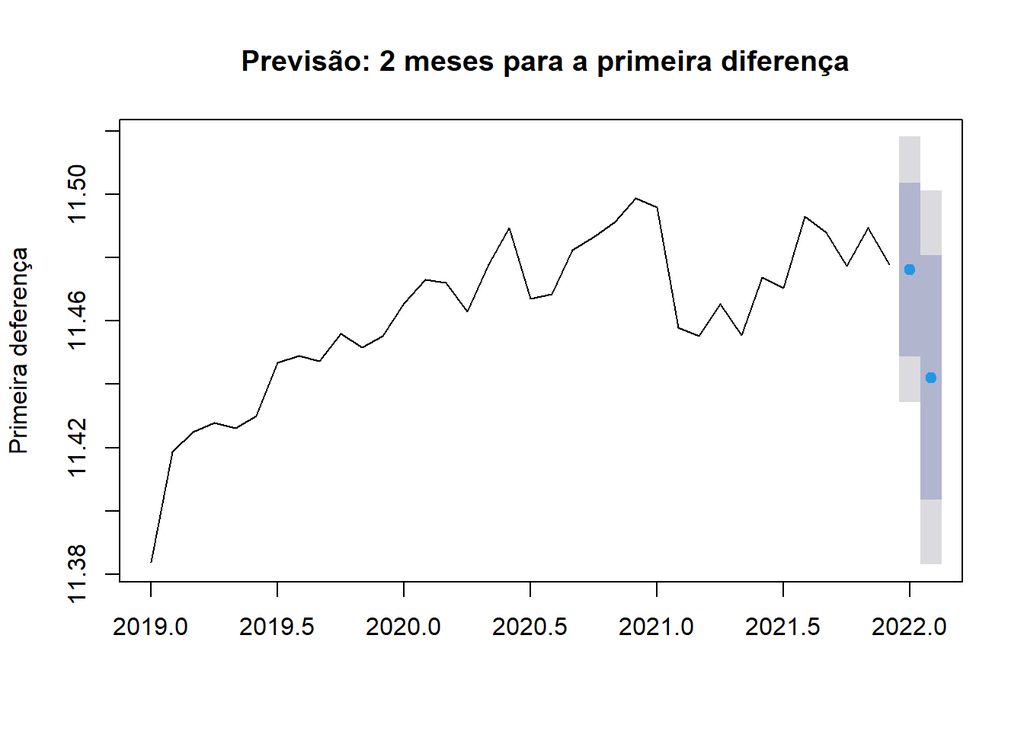

```r
pronostico1 = forecast(modelo2, h = 2)





 plot(pronostico1, type="l",main = " Previsão: 2 meses para a primeira diferença",ylab="Primeira deferença")
```

podemos comparar a previsões com os nossos dados de teste

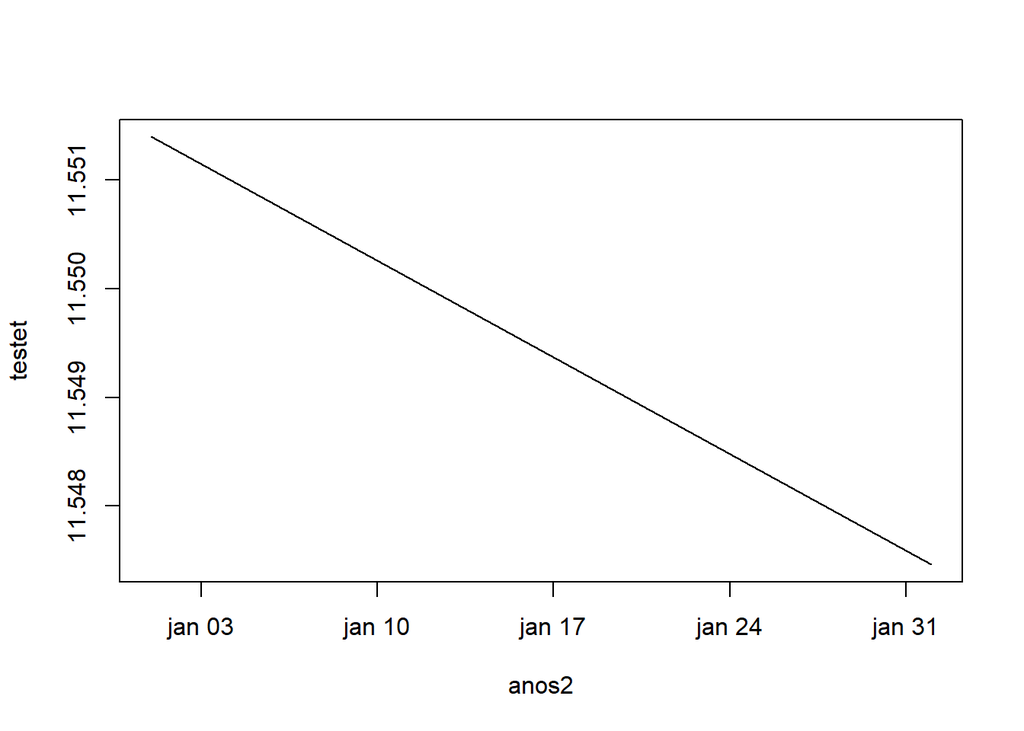

```r
teste<-py$df

teste<-teste[744:783,4]
testet<- log(ts(teste, start = c(2022,1),end = c(2022,2), freq=12))



 anos2 <- seq(as.Date("2022/1/1"),as.Date("2022/02/28"),"months")


  plot(anos2,testet,type ="l")
```

## Prevendo os próximos 12 meses usando o modelo Arima

Para executar a previsão dos próximos 12 meses vamos usar o parâmetro **h=12** no nosso **modelo2** dessa forma temos a seguinte previsão:

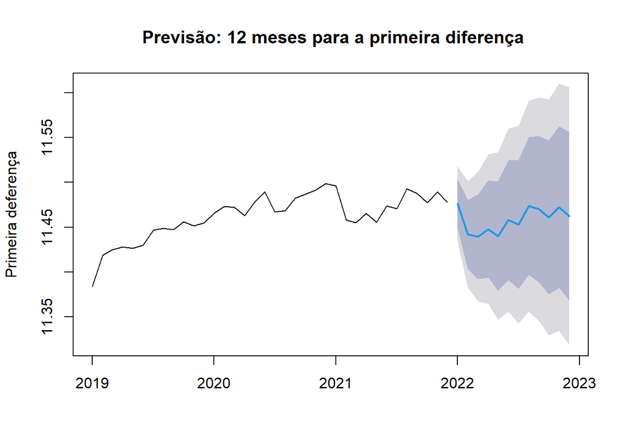

```r
doze_mes = forecast(modelo2, h = 12)





 plot(doze_mes, type="l",main = " Previsão: 12 meses para a primeira diferença",ylab="Primeira deferença")
```

Podemos perceber que quanto maior for o período da previsão ficará mais difícil de se obter uma boa estimativa , pois quanto maior for o tempo ,maior será os limites de variações da previsão feita com base no modelo utilizado.

# Acesse meus outros projetos :

Relatório sobre os testes paramétricos e não paramétricos :

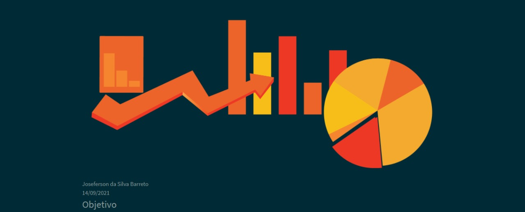

Análise Exploratória na linguagem Python :

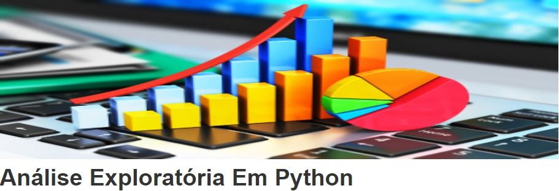

# Referências

Dividendos: o que são? Dá para viver disso?. Disponível em: https://blog.nubank.com.br/dividendos/ . Acesso em: 21 de março de 2022.

Stock-split (desdobramento de ações). Proteste_Investe. Disponível em: https://www.deco.proteste.pt/investe/lexicon/s/stock-split/ . Acesso em: 21 de março de 2022.

APLICAÇÃO DO MODELO DE PREVISÃO DE DEMANDA HOLTWINTERS EM UMA REGIONAL DE CORTE E DOBRA DE AÇO http://www.abepro.org.br/biblioteca/tn_wic_206_219_28345.pdf . Acesso em: 21 de março de 2022.